# Load Data

```python
import pandas as pd
df_UserProfiles = pd.read_csv('https://storage.googleapis.com/datalynn-datasets/interview-challenge/technology/Indeed_User_Engagement/df_UserProfiles.csv')
df_UserInteractions = pd.read_csv('https://storage.googleapis.com/datalynn-datasets/interview-challenge/technology/Indeed_User_Engagement/df_UserInteractions.csv')
```

[output not shown]

## Question 1

You notice that some users in the `UserProfiles` table have an unusually high value in the `SearchFrequency` column, possibly due to an error in tracking. Detect and visualize any outliers in the `SearchFrequency` column. Based on this, suggest a threshold beyond which values might be considered errors.

**Problem Solving Ideas and Tips:**

To detect and visualize outliers for the SearchFrequency column, we will:

Plot a boxplot which is a standardized way of displaying the distribution of data based on a five number summary: minimum, first quartile, median, third quartile, and maximum. Points outside the whiskers are considered as outliers. Additionally, we will calculate the IQR (Interquartile Range) for the SearchFrequency column. A common method to define a threshold for outliers is to consider data points outside 1.5 * IQR as outliers.

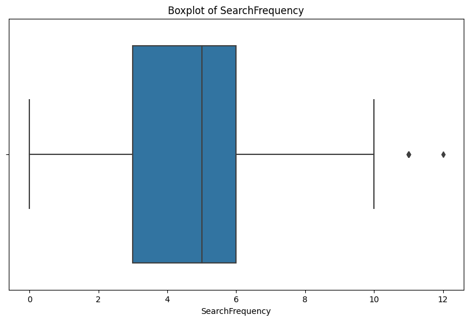

```
Suggested threshold for outliers: Values below -1.5 and above 10.5 might be considered errors.
```

```python
import pandas as pd
import matplotlib.pyplot as plt
import seaborn as sns

# Sample DataFrame initialization from the previous code
# df_UserProfiles

# Boxplot for SearchFrequency
plt.figure(figsize=(10,6))
sns.boxplot(x=df_UserProfiles['SearchFrequency'])
plt.title('Boxplot of SearchFrequency')
plt.show()

# Calculating IQR
Q1 = df_UserProfiles['SearchFrequency'].quantile(0.25)
Q3 = df_UserProfiles['SearchFrequency'].quantile(0.75)
IQR = Q3 - Q1

# Suggesting a threshold for outliers
lower_threshold = Q1 - 1.5 * IQR
upper_threshold = Q3 + 1.5 * IQR
print(f"Suggested threshold for outliers: Values below {lower_threshold} and above {upper_threshold} might be considered errors.")
```

## Question 2

Indeed wants to understand if certain demographics are more likely to engage with their personalized job alerts. Given the `UserProfiles` and `UserInteractions` tables, can you test if the probability of a user with a `JobPreference` of "Tech" opening a `JobAlertOpened` is significantly different from the rest of the population?

**Problem Solving Ideas and Tips:**

To determine if there's a statistically significant difference in the probability of a user with a JobPreference of "Tech" opening a JobAlertOpened compared to the rest of the population, we can use a hypothesis test. The Chi-Square test for independence is a popular choice for this kind of problem, where we're comparing categorical data.

H0 (null hypothesis): The probability of opening a JobAlertOpened is the same for users with JobPreference "Tech" and the rest of the population.

H1 (alternative hypothesis): The probability of opening a JobAlertOpened is different for users with JobPreference "Tech" compared to the rest of the population

```python
import pandas as pd
from scipy.stats import chi2_contingency

# Sample DataFrame initialization from the previous code
# df_UserProfiles, df_UserInteractions

# Merging the two tables on 'UserID'
merged_df = pd.merge(df_UserProfiles, df_UserInteractions, on='UserID')

# Creating a contingency table
contingency_table = pd.crosstab(merged_df['JobPreference'] == 'Tech', merged_df['JobAlertOpened'])
print(contingency_table)

# Performing the Chi-Square test
chi2, p, _, _ = chi2_contingency(contingency_table)
print(f"Chi-Square Value = {chi2}")
print(f"P-Value = {p}")

if p < 0.05:
    print("Reject the null hypothesis: There is a significant difference in the probability.")
else:
    print("Fail to reject the null hypothesis: There isn't a significant difference in the probability.")
```

```
JobAlertOpened  False  True
JobPreference
False             225    521
True               81    173
Chi-Square Value = 0.19150736578996835
P-Value = 0.6616650001388071
Fail to reject the null hypothesis: There isn't a significant difference in the probability.
```

## Question 3

To tailor marketing campaigns effectively, Indeed wants to predict if a user will click on a particular marketing campaign based on their profile. Using the `UserProfiles` and `UserInteractions` tables, develop a model where the target variable is `Clicked`. Specify the features you would choose and justify your choice. Also, discuss the performance metric that would be most relevant for this problem.  
*Target Variable:* Clicked (Boolean)

**Problem Solving Ideas and Tips:**

The goal here is to predict if a user will click on a particular marketing campaign based on their profile. This is a binary classification problem where our target variable is Clicked. We can employ a range of algorithms to handle binary classification, but logistic regression is a common starting point given its interpretability.

Feature selection is crucial. We want to incorporate data that we believe can help in making the prediction but exclude features that could introduce noise.

Features to consider:

Age: Different age groups might have different clicking behaviors. Gender: Gender could have an influence on clicking behavior. SearchFrequency: Users who search more often might be more engaged and likely to click. LastSearch: Recent searches might make a user more likely to click. JobPreference: Preference can indicate a user's current interest and influence clicking behavior.

Features to ignore:

UserID: This is just an identifier and has no predictive power. CampaignID (from UserInteractions): Since each user has a unique campaign in this synthetic data, it's unlikely to be predictive. Performance Metric: Since this is a binary classification problem, accuracy could be a metric of interest. However, if the data is imbalanced (more non-clicks than clicks), then F1-score or AUC-ROC might be more appropriate to ensure a balance between precision and recall.

```python
import pandas as pd
from sklearn.model_selection import train_test_split
from sklearn.linear_model import LogisticRegression
from sklearn.metrics import accuracy_score, classification_report

# Sample DataFrame initialization from the previous code
# df_UserProfiles, df_UserInteractions

# Merging the two tables on 'UserID'
merged_df = pd.merge(df_UserProfiles, df_UserInteractions, on='UserID')

# Feature selection
X = merged_df[['Age', 'Gender', 'SearchFrequency', 'LastSearch', 'JobPreference']]
y = merged_df['Clicked']

# One-hot encoding of categorical variables
X = pd.get_dummies(X, columns=['Gender', 'JobPreference'], drop_first=True)

# Splitting data into training and testing sets
X_train, X_test, y_train, y_test = train_test_split(X, y, test_size=0.2, random_state=42)

# Initializing and fitting the logistic regression model
clf = LogisticRegression(max_iter=1000)
clf.fit(X_train, y_train)

# Predicting and evaluating the model
y_pred = clf.predict(X_test)
print(f"Accuracy: {accuracy_score(y_test, y_pred)}")
print(classification_report(y_test, y_pred))
```

```
Accuracy: 0.59
              precision    recall  f1-score   support

       False       0.59      0.99      0.74       117
        True       0.67      0.02      0.05        83

    accuracy                           0.59       200
   macro avg       0.63      0.51      0.39       200
weighted avg       0.62      0.59      0.45       200
```

## Question 4

Indeed believes that users who have recently searched for jobs (`LastSearch` close to 0) are more likely to interact with content. However, this might vary based on the `JobPreference` category. Calculate the probability that a user with `LastSearch` less than 7 days (i.e., within the last week) has also read a particular type of content, say "InterviewTips", grouped by their `JobPreference`. Compare these probabilities among the different `JobPreference` categories and provide insights.

**Problem Solving Ideas and Tips:**

Filter the Merged Data:

Begin by filtering the combined data from both df_UserProfiles and df_UserInteractions. Only include entries where the LastSearch is less than 7 days. Probability Calculation:

For each category in JobPreference, determine the probability that a user read the content titled "InterviewTips". To do this, divide the number of users in a particular job preference category who read "InterviewTips" by the total number of users with that job preference. In mathematical terms: Let the numerator be the count of users who have a specific job preference and who also read "InterviewTips". Let the denominator be the total count of users who have that specific job preference. The probability for that category is then: Probability = Numerator/Denominator Visual Interpretation:

Once you have the probabilities for each category, it's useful to represent these numbers visually. A bar chart or similar visualization can help in quickly spotting variations in probabilities across different job preference categories. This in turn can aid in drawing conclusions or insights from the data.

```python
import pandas as pd

# Sample DataFrame initialization from the previous code
# df_UserProfiles, df_UserInteractions

# Merging the two tables on 'UserID'
merged_df = pd.merge(df_UserProfiles, df_UserInteractions, on='UserID')

# Filtering the data for LastSearch less than 7 days
recent_search_df = merged_df[merged_df['LastSearch'] < 7]

# Grouping by 'JobPreference' and calculating the probability
result = recent_search_df.groupby('JobPreference').apply(lambda group: sum(group['ContentRead'] == 'InterviewTips') / len(group)).reset_index()
result.columns = ['JobPreference', 'Probability']

print(result)
```

```
  JobPreference  Probability
0     Education     0.252688
1       Finance     0.275862
2    Healthcare     0.269006
3          Tech     0.236181
```